# ANOVA project

Michael Yun, Priyanshu Dey

## Collaboration rules:

Students are encouraged to work with a partner on this project. Be sure to register your team: “Canvas >> People >> ANOVA Project Teams” and write the full name of each teammate in the “author” line at the top of this Rmd document.

## Instructions

Write a report that includes an introduction to the data, appropriate EDA, model specification, the checking of conditions, and in context conclusions. To include sections in your report use the # as illustrated by the # Instructions for this section. Larger section headings have one #, smaller subsection headings have ## or ### or even ####. There should be a coherent and well-organized narrative in addition to appropriate code and figures. You may also reference your MLR project as a framework.

# Introduction

In this study, we examine the pricing of three popular automobile models—the Honda Civic, Ford F-150, and Jeep Cherokee—in two distinctly different geographic locations within the United States: State College, Pennsylvania (ZIP code 16801) and Charlotte, North Carolina (ZIP code 28207). This analysis aims to uncover potential pricing disparities and patterns based on vehicle model and geographical location. By analyzing data collected from Autotrader listings provided by St. Lawrence University’s dataset portal, we intend to identify how external factors such as location and internal factors like car model influence the pricing of used vehicles,as well as potential covariates include the mileage and year/age.

The selection of car models provides a broad spectrum of vehicle types and market segments:

Honda Civic: A staple in the compact car segment, known for its reliability and efficiency. Ford F-150: A leading model in the full-size pickup truck category, renowned for its capability and versatility. Jeep Cherokee: A popular SUV that balances off-road capability with on-road comfort.

The two chosen locations offer contrasting demographics and economic landscapes:

State College, PA (16801): Known primarily as a college town, home to Penn State University, which may influence vehicle demand and pricing,coded as 1. Charlotte, NC (28207): A major metropolitan area with a diverse economy and a larger market for various types of vehicles,coded as 0.

## Research Question

How does car model,location and mileage affect car prices, specifically examining how much of the variance in car prices can be attributed to differences in model and location after controlling for mileage?

### **Two-Way Factorial ANCOVA Model with Interaction**

#### **Hypotheses**

- **Null Hypotheses (H0):**
  - **H0:** Interaction between location and model does not significantly influence affect the price of cars when adjusting for mileage, meaning all models would have the same pricing adjusted for mileage.
- **Alternative Hypotheses (Ha):**
  - **Ha:** Interaction between location and model significantly affects the price of cars when adjusting for mileage.

# EDA

## Data collation

```r
#Load the datasets
sc_civic<-read.csv("https://raw.githubusercontent.com/Migueldesanta/Anova/main/16801_civic.csv")
nc_civic<-read.csv("https://raw.githubusercontent.com/Migueldesanta/Anova/main/28207_civic.csv")
sc_Cherokee<-read.csv("https://raw.githubusercontent.com/Migueldesanta/Anova/main/16801_Cherokee.csv")
nc_Cherokee<-read.csv("https://raw.githubusercontent.com/Migueldesanta/Anova/main/28207_Cherokee.csv")
sc_F150<-read.csv("https://raw.githubusercontent.com/Migueldesanta/Anova/main/16801_F150.csv")
nc_F150<-read.csv("https://raw.githubusercontent.com/Migueldesanta/Anova/main/28207_F150.csv")
# Add a new column 'location' to each datasets,SC coded as 1,NC coded as 0
sc_civic$location<-"state college"
nc_civic$location<-"Charlotte"
sc_Cherokee$location<-"state college"
nc_Cherokee$location<-"Charlotte"
sc_F150$location<-"state college"
nc_F150$location<-"Charlotte"
# Assigning the model names to each dataframe
sc_civic$model <- "Civic"
nc_civic$model <- "Civic"
sc_Cherokee$model <- "Cherokee"
nc_Cherokee$model <- "Cherokee"
sc_F150$model <- "F150"
nc_F150$model <- "F150"
#perform full join to merge the data sets
combined_data <- sc_civic %>%full_join(nc_civic)%>%full_join(sc_Cherokee)%>%full_join(nc_Cherokee)%>%full_join(sc_F150)%>%full_join(nc_F150)
# Add a new column 'age'
combined_data $age <- 2024 - combined_data $year
# Remove NA values specifically in 'mileage' and 'price'
combined_data <- na.omit(combined_data, cols = c("mileage", "price"))
# Remove rows where 'mileage' or 'price' equals zero
combined_data <- combined_data[combined_data$mileage != 0 & combined_data$price != 0, ]
```

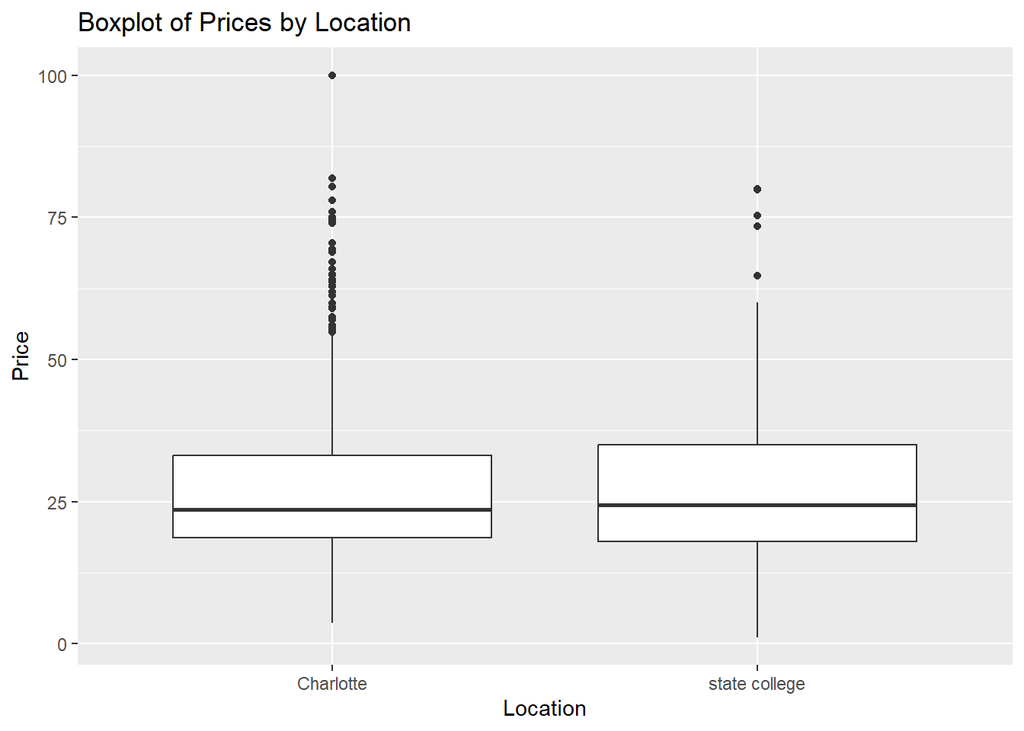

```r
# Boxplot for price by location
ggplot(combined_data, aes(x = location, y = price)) +
  geom_boxplot() +
  labs(title = "Boxplot of Prices by Location", x = "Location", y = "Price")
```

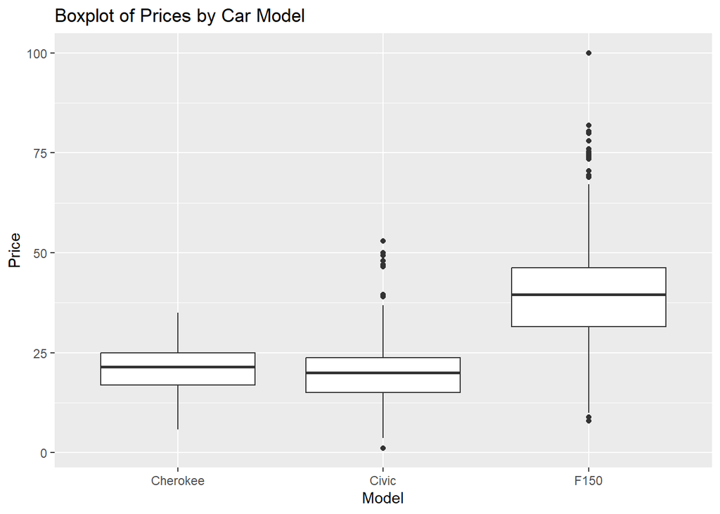

```r
# Boxplot for price by model
ggplot(combined_data, aes(x = model, y = price)) +
  geom_boxplot() +
  labs(title = "Boxplot of Prices by Car Model", x = "Model", y = "Price")
```

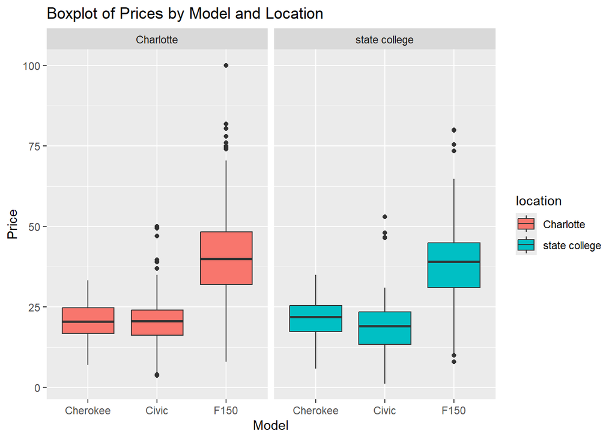

```r
# Boxplot for price by model and location interaction
ggplot(combined_data, aes(x = model, y = price, fill = location)) +
  geom_boxplot() +
  labs(title = "Boxplot of Prices by Model and Location", x = "Model", y = "Price") +
  facet_wrap(~ location)
```

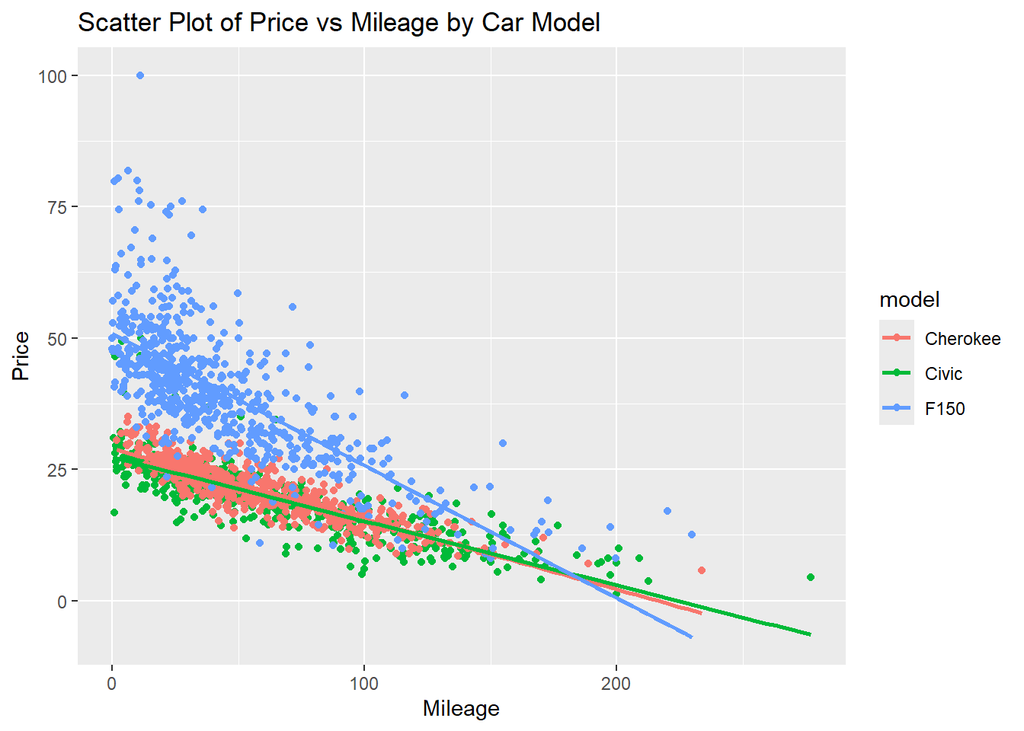

```r
# Scatter plot for price vs mileage colored by model
ggplot(combined_data, aes(x = mileage, y = price, color = model)) +
  geom_point() +
  geom_smooth(method = "lm", se = FALSE) +
  labs(title = "Scatter Plot of Price vs Mileage by Car Model", x = "Mileage", y = "Price")
```

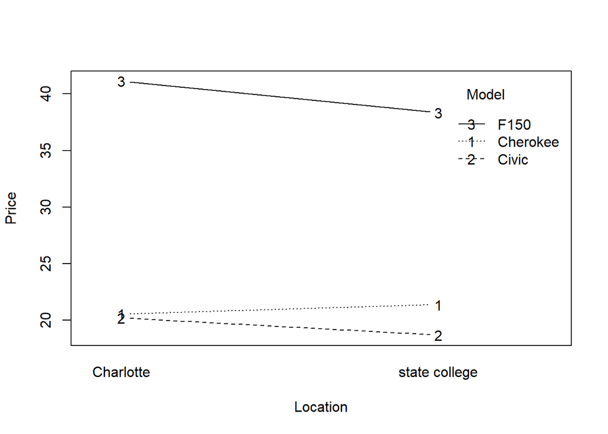

```r
# Interaction plot for price by location and model
interaction.plot(combined_data$location,combined_data$model, combined_data$price,
                 fun = mean, type = "b", legend = TRUE,
                 xlab = "Location", ylab = "Price", trace.label = "Model")
```

Image 1: Boxplot of Prices by Location

This boxplot displays the distribution of prices for each location, without considering the car model. The median price in Charlotte appears to be lower than in State College. There are some outliers (dots above the whiskers) in both locations, indicating the presence of extremely high-priced vehicles.

Image 2: Boxplot of Prices by Car Model

Image 3: Boxplot of Prices by Model and Location

Image 4: Scatter Plot of Price vs. Mileage by Car Model

This scatter plot displays the relationship between price and mileage for each car model, with different colors representing different models. There is a clear negative correlation between price and mileage, indicating that vehicles with higher mileage tend to have lower prices. The F150 model generally has higher prices compared to the Civic and Cherokee for similar mileage levels. The Civic and Cherokee models exhibit a more overlapping range of prices and mileages.

Image 5: Line Plot of Prices by Location and Model

# Model Fitting

```r
#ANCOA
anova_model <- aov(lm(price ~ model+mileage+location+location*model, data = combined_data))
summary(anova_model)
```

```
##                  Df Sum Sq Mean Sq  F value   Pr(>F)
## model             2 147173   73586 1878.772  < 2e-16 ***
## mileage           1  72619   72619 1854.071  < 2e-16 ***
## location          1   1250    1250   31.923 1.88e-08 ***
## model:location    2    539     270    6.887  0.00105 **
## Residuals      1695  66389      39
## ---
## Signif. codes:  0 '***' 0.001 '**' 0.01 '*' 0.05 '.' 0.1 ' ' 1
```

1. **Model*location :**
   - **Degrees of Freedom (Df):** The model has 2 degrees of freedom, which suggests there are three different car models being compared.
   - **Sum of Squares (Sum Sq):** The Sum Sq for the model is 539, which is a measure of the total variation attributed to the differences in the mean prices across the car models.
   - **Mean Square (Mean Sq):** The Mean Sq, which is the Sum Sq divided by the Df, is 270. This represents the average variation per model category.
   - **F-value:** The F-value is 6.887, which is substantially large, indicating a strong effect of the model on price.
   - **p-value (Pr(>F)):** The p-value is less than 0.00105, which is highly significant. This means interaction between location and model significantly affects the price of cars when adjusting for mileage.

   The ANCOVA results demonstrated that both the car model and location significantly affected car prices (p < 0.05 for the interaction term). Thus, we reject the null hypotheses (H0) and accept the alternative hypotheses (Ha), concluding that different car models and locations significantly affect car prices, after adjusting mileage(p=0.00105).

# Assess Model Conditions

## MLR

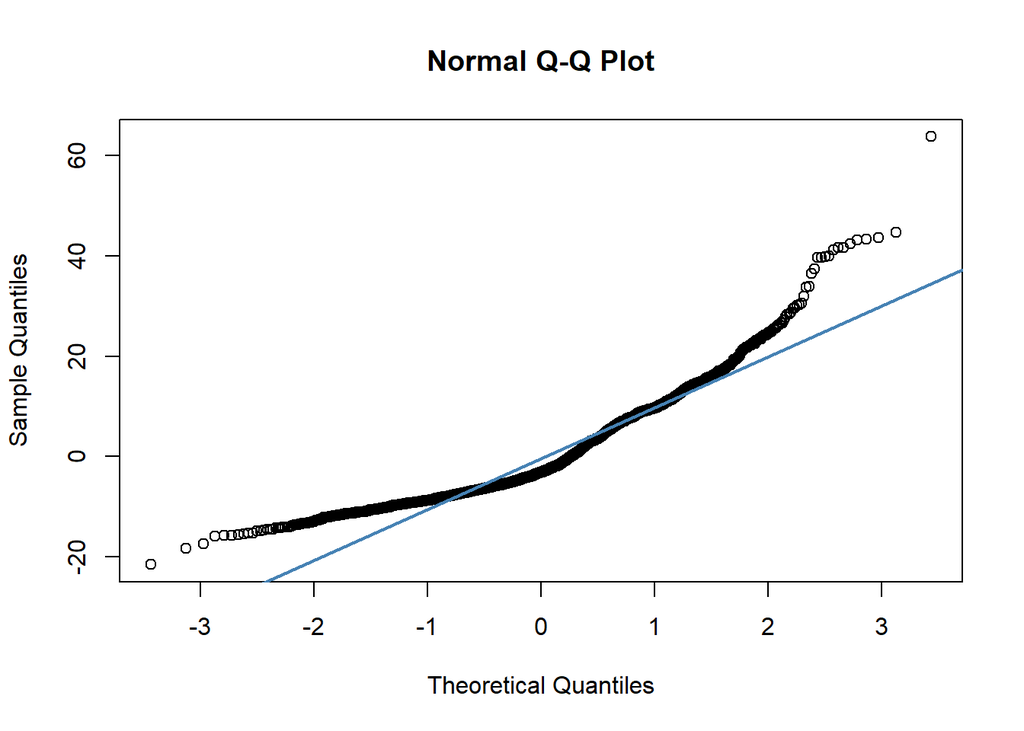

```r
# Fitting the MLR model
mlr_model <- lm(price ~ mileage, data = combined_data)


# Check for normality of residuals
qqnorm(residuals(mlr_model))
qqline(residuals(mlr_model), col = "steelblue", lwd = 2)
```

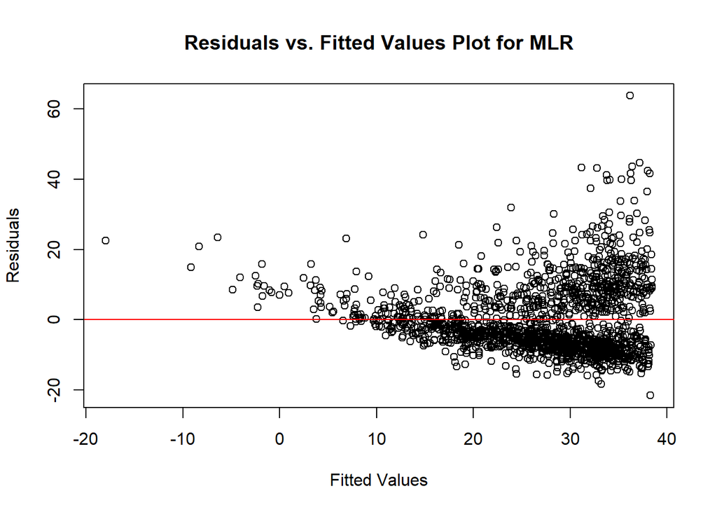

```r
# Check for homoscedasticity
plot(fitted(mlr_model), residuals(mlr_model),
     xlab = "Fitted Values", ylab = "Residuals",
     main = "Residuals vs. Fitted Values Plot for MLR")
abline(h = 0, col = "red")
```

### Comments

#### Normality

The QQ-plot shows that the tail ends are not symmetric with the data which could lead to some issues with normality.

#### Equal Variance

The Residuals seem to have non constant variance in which the points seem to be skewed to the right

#### Randomness

The data collected from the source seems to be a random sampling of data points.

## Anova

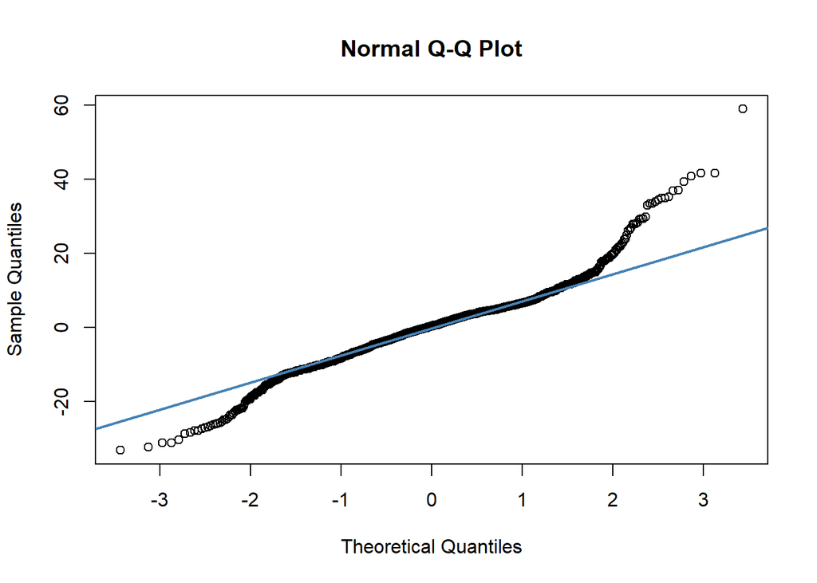

```r
# Fitting the ANOVA model
anova_model1 <- aov(price ~ model + location + model:location, data = combined_data)

# Check for normality of residuals
qqnorm(residuals(anova_model1))
qqline(residuals(anova_model1), col = "steelblue", lwd = 2)
```

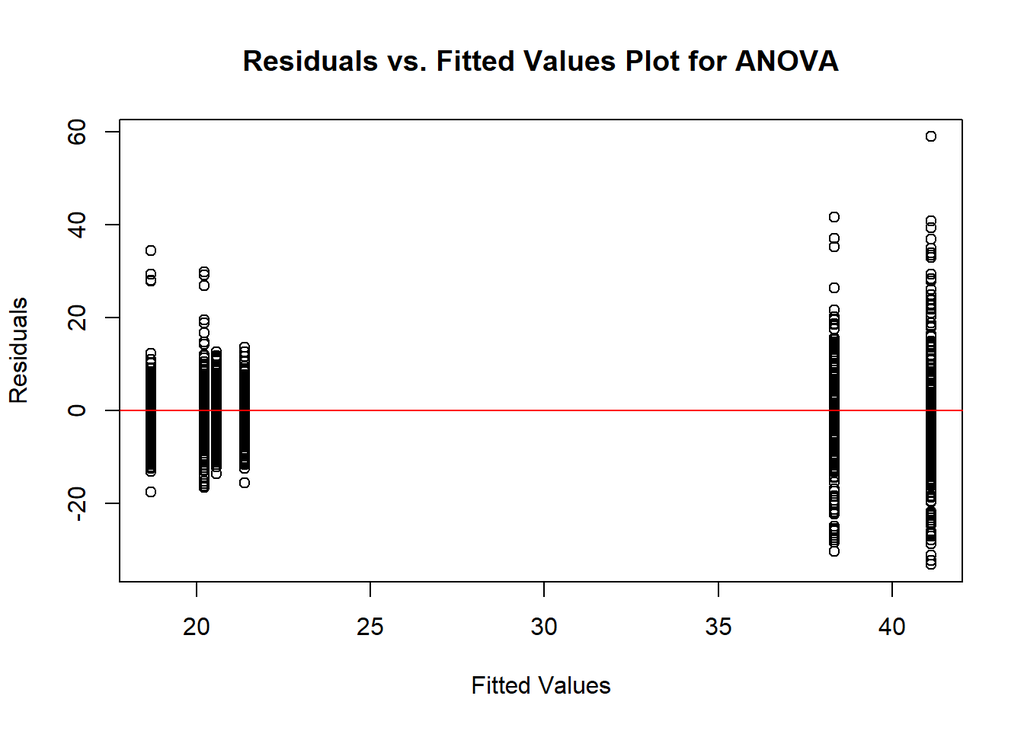

```r
# Check for homoscedasticity
plot(fitted(anova_model1), residuals(anova_model1),
     xlab = "Fitted Values", ylab = "Residuals",
     main = "Residuals vs. Fitted Values Plot for ANOVA")
abline(h = 0, col = "red")
```

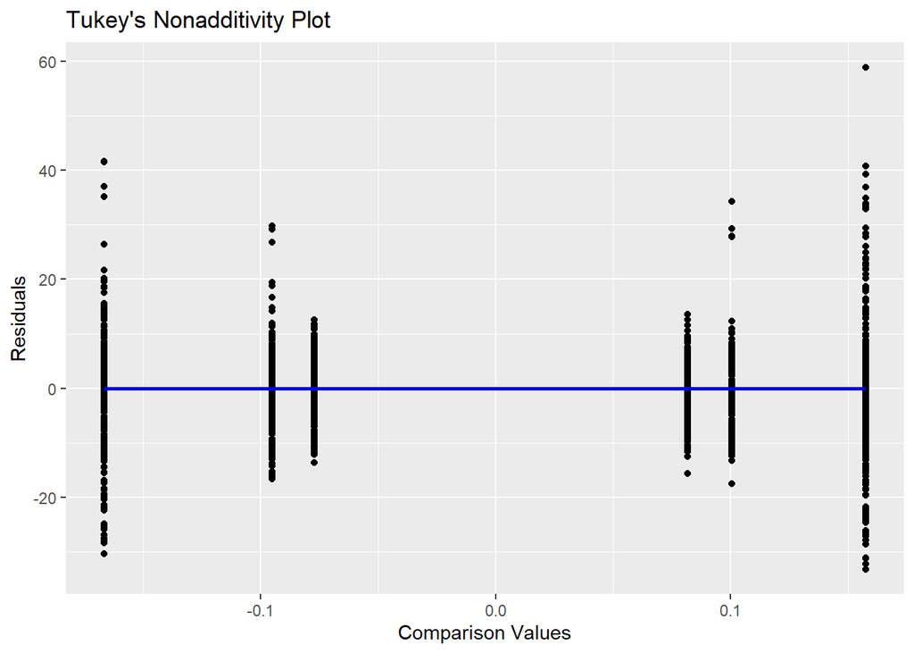

```r
library(dplyr)
library(ggplot2)

# Fit the model
model_fit <- lm(price ~ model + location + model:location, data = combined_data)

# Summarize overlays with needed effects
Data_Overlays <- combined_data %>%
  mutate(
    grand_mean = mean(price), # Calculate the grand mean of price
    model_effect = ave(price, model, FUN = mean) - grand_mean, # Effect of each model
    location_effect = ave(price, location, FUN = mean) - grand_mean # Effect of each location
  ) %>%
  mutate(
    # Compute residuals from the model
    Residuals = residuals(model_fit),
    # Compute Comparison Values for Tukey Nonadditivity Plot
    Comparison_Values = model_effect * location_effect / grand_mean
  )

# Plot residuals vs comparison values & fit simple linear regression
ggplot(Data_Overlays, aes(x = Comparison_Values, y = Residuals)) +
  geom_point() +
  geom_smooth(method = "lm", se = FALSE, color = "blue") +
  labs(
    title = "Tukey's Nonadditivity Plot",
    x = "Comparison Values",
    y = "Residuals"
  )
```

```r
# Fit a linear model to residuals vs comparison values
comparison_fit <- lm(Residuals ~ Comparison_Values, data = Data_Overlays)
summary(comparison_fit)
```

```
##
## Call:
## lm(formula = Residuals ~ Comparison_Values, data = Data_Overlays)
##
## Residuals:
##     Min      1Q  Median      3Q     Max
## -33.128  -5.171   0.371   4.654  58.880
##
## Coefficients:
##                     Estimate Std. Error t value Pr(>|t|)
## (Intercept)       -4.536e-16  2.194e-01       0        1
## Comparison_Values  2.080e-14  1.831e+00       0        1
##
## Residual standard error: 9.05 on 1700 degrees of freedom
## Multiple R-squared:  1.092e-31,  Adjusted R-squared:  -0.0005882
## F-statistic: 1.856e-28 on 1 and 1700 DF,  p-value: 1
```

```r
# Calculate the optimal transformation power
slope <- coef(comparison_fit)["Comparison_Values"]
power <- 1 - slope
power <- ifelse(power == 0, "logarithmic transformation", power)

# Output the optimal transformation
print(paste("The transformation power is", power))
```

```
## [1] "The transformation power is 0.999999999999979"
```